# Screening to Diagnostic Timeliness

01 February, 2022

# Purpose

This document is meant to demonstate the timeliness of a diagnostic mammogram following a screening mammogram with a birads 0. Two metrics are displayed below.

- The percent of patients receiving a follow up mammogram beyond 7 calendar days.
- The average number of days between the two mammograms, omitting those records where the time between is greater than 30 calendar days–acknowledging that patient apprehension is beyond the system’s control

Note that lower is better for both metrics.  
The data are arbitrarily limited to the last four full calendar years, up to the end of the most recently completed quarter. In the event that a patient received multiple mammograms of either type, the latest screening and earliest diagnostic are those considered. A handful of observations were omitted due to data entry errors. All confidence intervals displayed below are at the 95% level.

# Percent

A total of 43625 screening-diagnostic instances are considered.

## System level

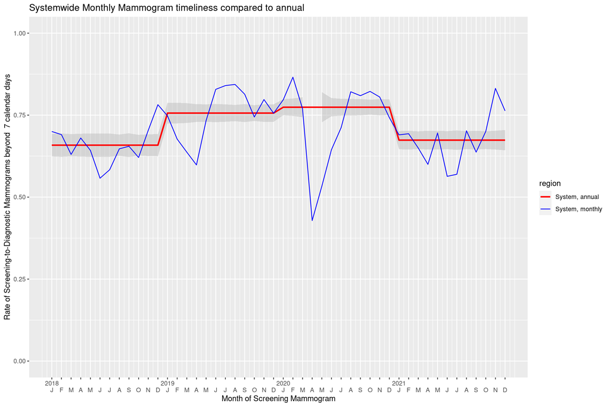

## Regions

### North

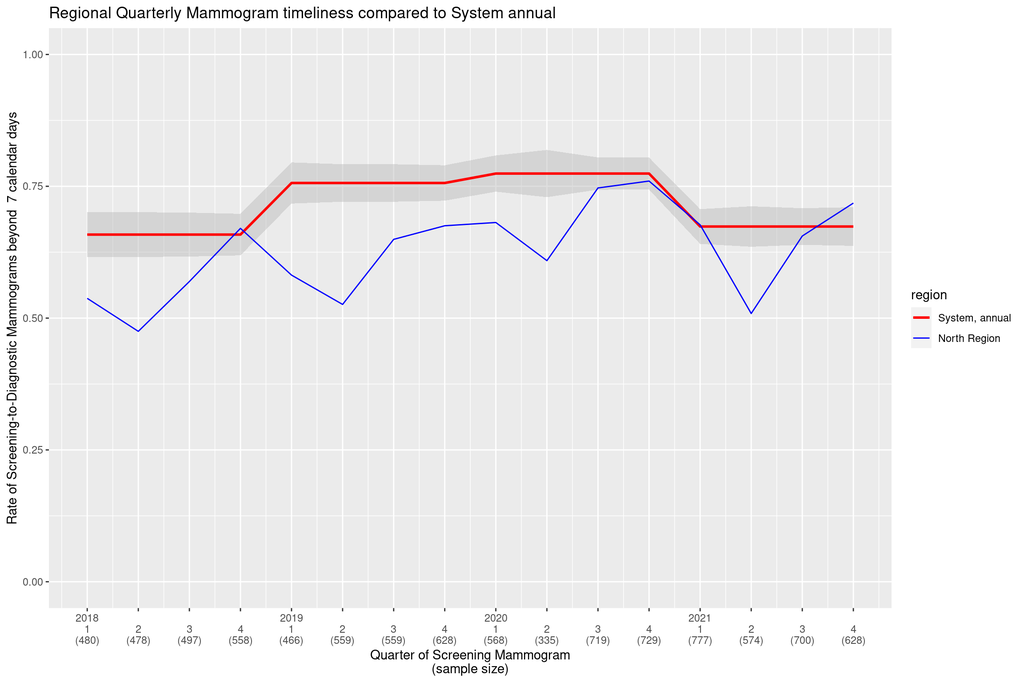

### Central

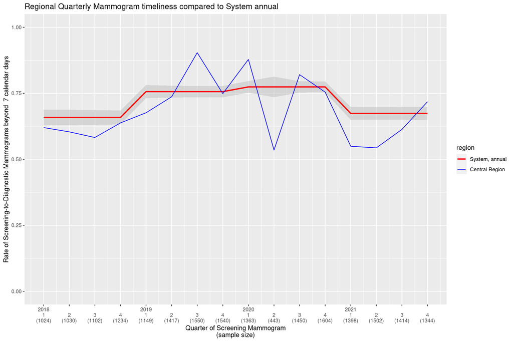

### South

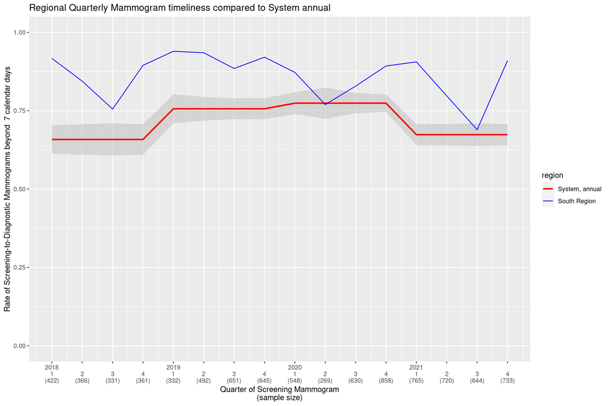

### Southwest

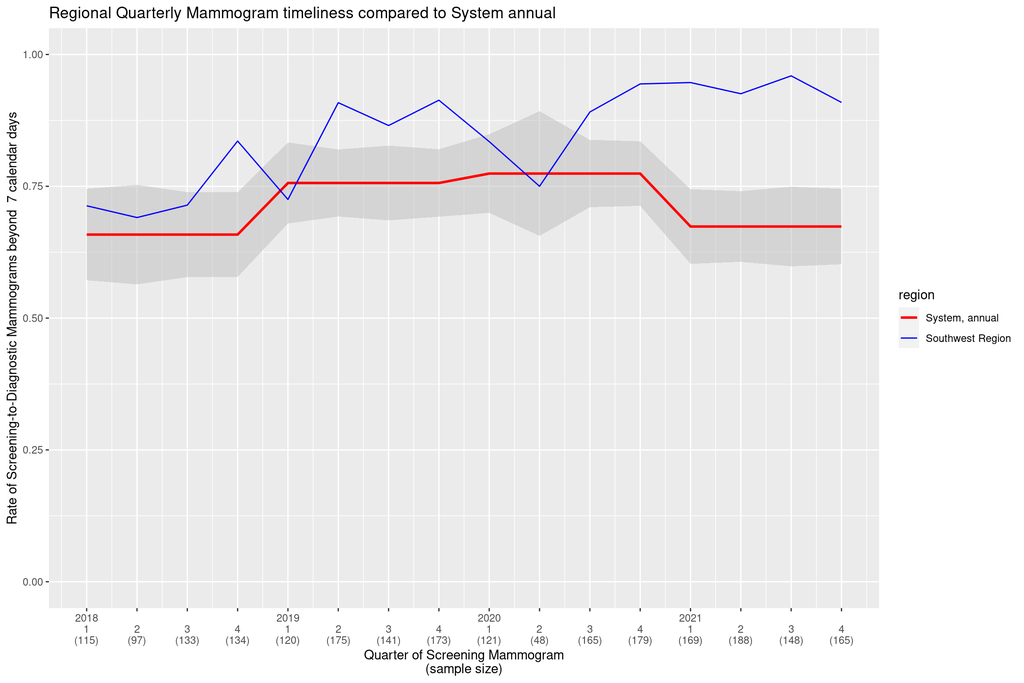

## Most Recent Quarter

The table below is the regions’ performance for the most recently completed quarter.

| **Region** | North | Central | South | Southwest |
| --- | --- | --- | --- | --- |
| **Percent** | 71.82% | 71.8% | 91% | 90.91% |

# Average

A total of 40861 screening-diagnostic records are considered below. 2764 records or 6.34 percent of the total instances had a gap larger than 30 calendar days and were omitted from the analysis.

## System

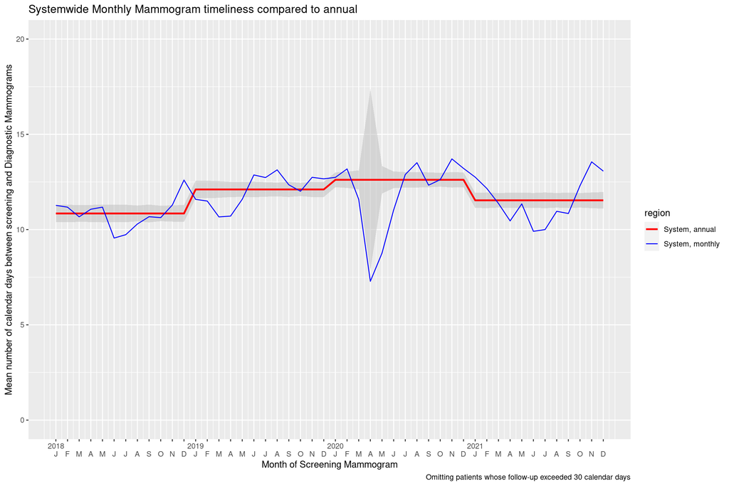

## Regions

### North

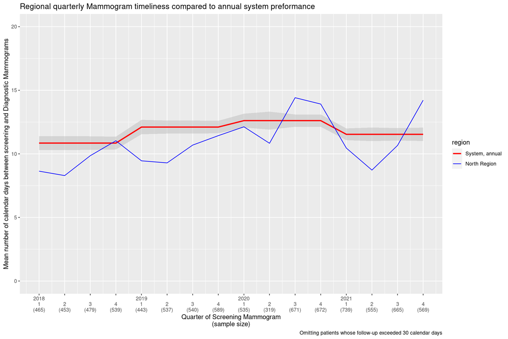

### Central

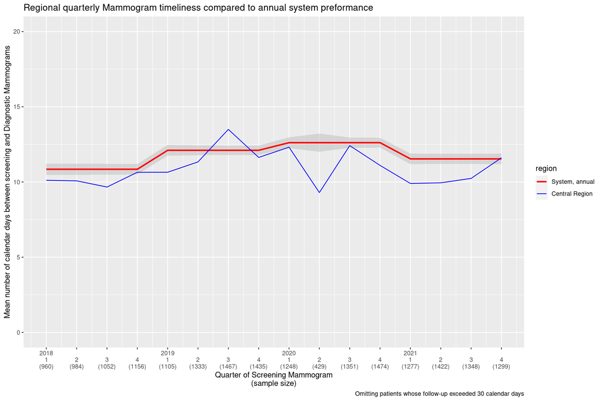

### South

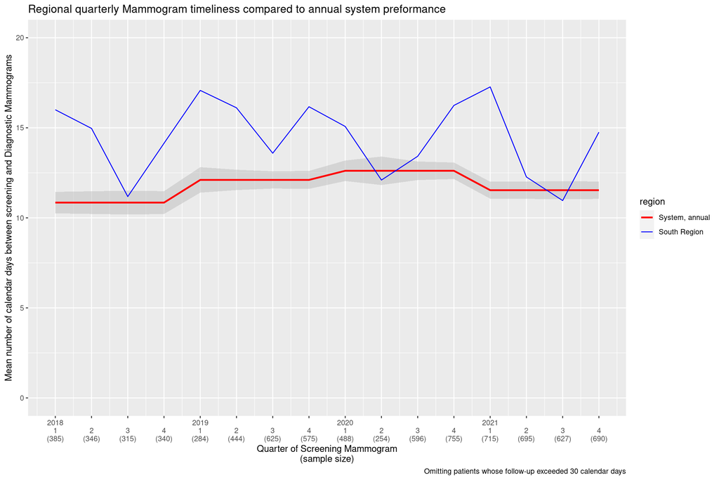

### Southwest

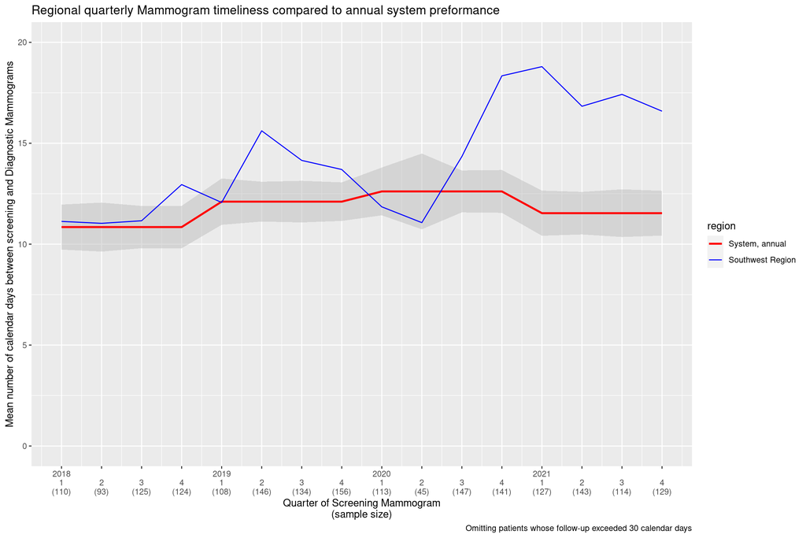

## Most Recent Quarter

The table below is the regions’ performance for the most recently completed quarter.

| **Region** | North | Central | South | Southwest |
| --- | --- | --- | --- | --- |
| **Average** | 14.22 | 11.61 | 14.76 | 16.59 |